# case study2_4.8

## Case 2 results using SQL Sever

Jinwen Li

### 1.asked information

SQL query codes can be found using the link:https://github.com/jinwen0826/case_study0409

```python
result=pd.DataFrame({'Year':['2017','2016','2015'],
                     'Trev_curr':['31417495.03','25730943.59','29036749.19'],
                     'Newcust_rev':['21769213.01','17206366.90','N/A'],
                     'Ecu_growth':['1123705.33','N/A','N/A'],
                     'Revlost_att':['16146518.63','20551216.15','N/A'],
                     'Ecu_revcurr':['9648282.02','8524576.69','N/A'],
                     'Ec_revp':['8524576.69','N/A','N/A'],
                     'Totalc_curr':['249987','204646','231294'],
                     'Totalc_p':['204646','231294','N/A'],
                     'Number_new_cus':['173449','136891','N/A'],
                     'Number_lost_cus':['128108','163539','N/A']

                    })
print(result)
```

```
   Year    Trev_curr  Newcust_rev  Ecu_growth  Revlost_att Ecu_revcurr  \
0  2017  31417495.03  21769213.01  1123705.33  16146518.63  9648282.02
1  2016  25730943.59  17206366.90         N/A  20551216.15  8524576.69
2  2015  29036749.19          N/A         N/A          N/A         N/A

      Ec_revp Totalc_curr Totalc_p Number_new_cus Number_lost_cus
0  8524576.69      249987   204646         173449          128108
1         N/A      204646   231294         136891          163539
2         N/A      231294      N/A            N/A             N/A
```

### Notes:

1.Trev_curr: Total revenue for the current year  
2.Newcust_rev: New Customer Revenue  
3.Ecu_growth: Existing Customer Growth  
4.Revlost_att:Revenue lost from attrition 5.Ecu_revcurr:Existing Customer Revenue Current Year  
6.Ec_revp:Existing Customer Revenue Prior Year  
7.Totalc_curr:Total Customers Current Year  
8.Totalc_p: Total Customers Previous Year  
9.Number_new_cus:New Customers  
10.Number_lost_cus:Lost Customers

#### 1.Total revenue for the current year

--The total revenue for the current year(2017) is 31417495.0300001  
--The total revenue for the current year(2016) is 25730943.5900001  
--The total revenue for the current year(2015) is 29036749.19

#### 2.New Customer Revenue

--New Customer Revenue for 2017 is 21769213.01, for 2016 is 17206366.9.

#### 3.Existing Customer Growth

-- Existing Customer Growth for year 2017 is 9648282.02000003-8524576.68999998= 1123705.33000005  
-- For here, we can only calculate the Existing Customer Growth for year 2017 because we don't know the  
-- existing revenue in year 2015, so we cannot get the Existing Customer Growth for 2016.

#### 4. Revenue lost from attrition

-- Here, we define the Revenue lost from attrition is the customers who bought goods last year but don't buy  
-- goods current year, and the lost is the value of goods they bought last year.

--The revenue lost from attrition in 2017 is 16146518.63, in 2016 is 20551216.15.

#### 5.Existing Customer Revenue Current Year

-- The existing customer revenue for year 2017 is 9648282.02000002, and for year 2016 is 8524576.69.

#### 6.Existing Customer Revenue Prior Year

-- For year 2017, the prior year is 2016, and the 2016 existing customer revenue is 8524576.69.

#### 7.Total Customers Current Year

--The total customers for current year 2017 is 249987，for year 2016 is 204646, for year 2015 is 231294.

#### 8.Total Customers Previous Year

--For year 2017, the previous year is 2016, the total customers is 204646.  
-- for year 2016, the previous year is 2015, the total customers is 231294.

#### 9.New Customers list

for year 2017:  
-- The total number of new customers for 2017 is 173449 and the top 10 of new customers is below.

fuyjaexmoh@gmail.com  
qvjfterwnk@gmail.com  
uxilnjipqh@gmail.com  
bcxekwoaor@gmail.com  
zhlvymbfwx@gmail.com  
fdkiioqtli@gmail.com  
vcihdhamko@gmail.com  
mqptqupwfa@gmail.com  
zxdpwkylvf@gmail.com  
vpsfdhgrfo@gmail.com

for year 2016: -- The total number of new customers for 2016 is 136891 and the top 10 of new customers is below.  
mwrossuukz@gmail.com  
gkwsoupawk@gmail.com  
vlyigtgfzs@gmail.com  
yfirychuhk@gmail.com  
trnzgqinuu@gmail.com  
hhxxpwlakg@gmail.com  
xshhioxkjs@gmail.com  
xypcivocfw@gmail.com  
hoyilazseb@gmail.com  
dkbsemibna@gmail.com

#### 10.Lost Customers list

for year 2017:  
-- for year 2017, the number of lost customers is 128108, and the top 10 of the lost customers is below.

gkwsoupawk@gmail.com  
trnzgqinuu@gmail.com  
hhxxpwlakg@gmail.com  
lfeafnigbu@gmail.com  
cemerinvsn@gmail.com  
wkgndosxgd@gmail.com  
xshhioxkjs@gmail.com  
ujelzbtqer@gmail.com  
gmsayrrlrm@gmail.com  
whnnmusxsc@gmail.com

for year 2016:  
-- for year 2016, the number of lost customers is 163539, and the top 10 of the lost customers is below.

sxabypbfhj@gmail.com  
cyksxkrbby@gmail.com  
fosfxhsnqg@gmail.com  
yuozotbyus@gmail.com  
lrafxvxavj@gmail.com  
zufomelpjp@gmail.com  
ihvfzxfjyd@gmail.com  
nhknapwsbx@gmail.com  
irvstayzjd@gmail.com  
jawkygcvwx@gmail.com

### 2.import data using python

```python
import pandas as pd
import numpy as np
from scipy import stats
import matplotlib.pyplot as plt
```

```python
customers = pd.read_csv('casestudy.csv') #customers
```

```python
customers.head(10)
```

|  | Unnamed: 0 | customer_email | net_revenue | year |
| --- | --- | --- | --- | --- |
| 0 | 0 | nhknapwsbx@gmail.com | 249.92 | 2015 |
| 1 | 1 | joiuzbvcpn@gmail.com | 87.61 | 2015 |
| 2 | 2 | ukkjctepxt@gmail.com | 168.38 | 2015 |
| 3 | 3 | gykatilzrt@gmail.com | 62.40 | 2015 |
| 4 | 4 | mmsgsrtxah@gmail.com | 43.08 | 2015 |
| 5 | 5 | mobvusnzfr@gmail.com | 39.44 | 2015 |
| 6 | 6 | kxwkqvacsv@gmail.com | 171.46 | 2015 |
| 7 | 7 | iqmnugdcjs@gmail.com | 111.99 | 2015 |
| 8 | 8 | baiikostmd@gmail.com | 170.70 | 2015 |
| 9 | 9 | lfeafnigbu@gmail.com | 54.99 | 2015 |

### Form 1

From the form below，there is an interesting observation.We can see the mean of three years net revenue are all around 125, the minimum are all 1.0, the maximum of three years net revenue are all 250.

```python
customers.groupby('year').net_revenue.agg(['sum', 'min', 'mean', 'max','median'])
```

| year | sum | min | mean | max | median |
| --- | --- | --- | --- | --- | --- |
| 2015 | 29036749.19 | 1.0 | 125.540434 | 250.0 | 125.655 |
| 2016 | 25730943.59 | 1.0 | 125.733919 | 250.0 | 125.760 |
| 2017 | 31417495.03 | 1.0 | 125.676515 | 250.0 | 125.810 |

### Plots 1

From the plots below, we can see the distributions of net_revenue in three years are all very even. Thus, we can see  
customers don't have any perferance about each price points.

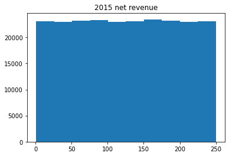

```python
net_revenue2015=customers[customers.year==2015]['net_revenue']
plt.hist(net_revenue2015)
plt.title('2015 net revenue')
```

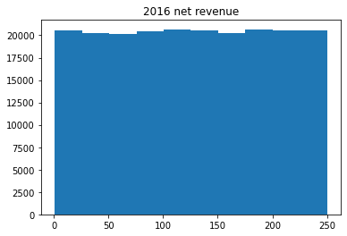

```python
net_revenue2016=customers[customers.year==2016]['net_revenue']
plt.hist(net_revenue2016)
plt.title('2016 net revenue')
```

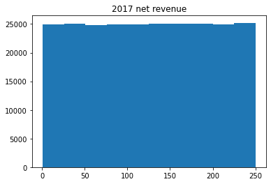

```python
net_revenue2017=customers[customers.year==2017]['net_revenue']
plt.hist(net_revenue2017)
plt.title('2017 net revenue')
```

### Plots 2

From the plots below,we can see the total net revenue and total customers of 2015-2017 , and we can see there is a tendency to go down and then up both on the total net revenue and total number of customers.

From the second plot below, we can see there is a coincide on the plot, this is a very interesting thing.So each customer contributes the same amount of sales growth, as long as there is a customer increase, there will be a unit of sales growth.

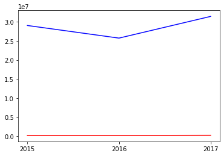

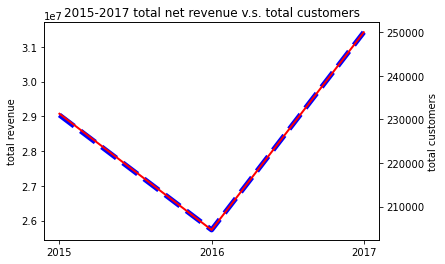

```python
result['Trev_curr'] = result['Trev_curr'].astype(float, errors = 'raise')
total_revenue=result['Trev_curr']
result['Totalc_curr'] = result['Totalc_curr'].astype(float, errors = 'raise')
total_customers=result['Totalc_curr']
x=['2015','2016','2017']
y1=[total_revenue[2],total_revenue[1],total_revenue[0]]
plt.plot(x,y1,label='total revenue',color='b')
y2=[total_customers[2],total_customers[1],total_customers[0]]
plt.plot(x,y2,label ='total customers',color='r')
fig,ax1=plt.subplots()
ax2=ax1.twinx()
ax1.plot(x,y1,'b',linewidth='5',linestyle='--')
ax2.plot(x,y2,'r',linewidth='2')
ax1.set_ylabel('total revenue')
ax2.set_ylabel('total customers')
plt.title('2015-2017 total net revenue v.s. total customers')
```

### Plot 3

From the plot below, we can see the new customer revenue is also increasing.

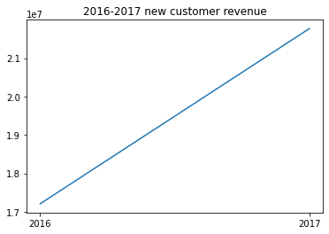

```python
x=['2016','2017']
y=[17206366.90,21769213.01]
plt.plot(x,y)
plt.title('2016-2017 new customer revenue')
```

### Plots 4

From the plots below, the organe line represents the number of new customers, the blue one represents the number of lost customers. We can know, in 2016, the number of lost customers is bigger than the number of new customers, which is a bad thing. However, in 2017, the number of new customers is larger than the number of lost customers which is a good thing for the company.

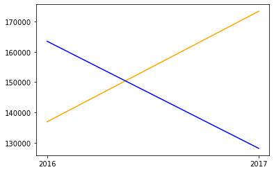

[figure not shown]

```python
x=['2016','2017']
y1=[136891,173449]
plt.plot(x,y1,label='number of new_customers',color='orange')
y2=[163539,128108]
plt.plot(x,y2,label ='number of lost_customers',color='b')
fig,ax1=plt.subplots()
ax2=ax1.twinx()
ax1.plot(x,y1,'orange',linewidth='5',linestyle='--')
ax2.plot(x,y2,'b',linewidth='2')
ax1.set_ylabel('number of new_customers')
ax2.set_ylabel('number of lost_customers')
plt.title('2016-2017 number of new customers v.s. number of lost customers')
```